# Analysis of results

Julia Romanowska

2019-06-06

# Pre-processing

Some rearranging of tables

Here are all the 130 unique SNPs:

```
##   [1] "rs7964474"  "rs999783"   "rs4982619"  "rs7945550"  "rs880813"
##   [6] "rs2280025"  "rs11584506" "rs10897066" "rs2032442"  "rs163684"
##  [11] "rs8025763"  "rs13008096" "rs4699228"  "rs2723057"  "rs7201659"
##  [16] "rs2151225"  "rs7197476"  "rs2367283"  "rs2914354"  "rs7209652"
##  [21] "rs10097386" "rs2383162"  "rs10738571" "rs7419201"  "rs7541537"
##  [26] "rs7042192"  "rs4977848"  "rs7920088"  "rs12740826" "rs13173741"
##  [31] "rs10757168" "rs8181543"  "rs168283"   "rs17408603" "rs11624380"
##  [36] "rs2177971"  "rs7943401"  "rs3793861"  "rs4394682"  "rs7087489"
##  [41] "rs2302304"  "rs2689128"  "rs9572250"  "rs4875398"  "rs3909551"
##  [46] "rs9371494"  "rs8101981"  "rs7939975"  "rs10495767" "rs11673884"
##  [51] "rs6489630"  "rs3815311"  "rs358017"   "rs7082286"  "rs921743"
##  [56] "rs10764037" "rs8112256"  "rs4569521"  "rs6830509"  "rs9503155"
##  [61] "rs10496410" "rs7579926"  "rs2294035"  "rs6975650"  "rs4876274"
##  [66] "rs2245225"  "rs927318"   "rs10735337" "rs6427247"  "rs12669493"
##  [71] "rs13255561" "rs12242535" "rs943881"   "rs10491327" "rs7232492"
##  [76] "rs11242213" "rs34352212" "rs1990185"  "rs521419"   "rs10763707"
##  [81] "rs814518"   "rs4693142"  "rs4454616"  "rs2904096"  "rs2290682"
##  [86] "rs6532013"  "rs1868368"  "rs6807522"  "rs17604550" "rs12883776"
##  [91] "rs7234787"  "rs4310561"  "rs3800036"  "rs2237360"  "rs7793050"
##  [96] "rs7766106"  "rs2809964"  "rs3859121"  "rs1092733"  "rs7559678"
## [101] "rs2366837"  "rs10084852" "rs6446389"  "rs2242909"  "rs595536"
## [106] "rs6726527"  "rs12733019" "rs17793145" "rs4973310"  "rs8072885"
## [111] "rs1889976"  "rs259395"   "rs10798004" "rs12431484" "rs10518981"
## [116] "rs1940698"  "rs171477"   "rs9862866"  "rs865585"   "rs17591732"
## [121] "rs12630106" "rs7316350"  "rs7336296"  "rs1499916"  "rs7153574"
## [126] "rs6439772"  "rs1348564"  "rs2360838"  "rs12204808" "rs1407555"
```

## Getting the information about the SNPs from ensembl

For later use, it’s good to retrieve the newest information from ensembl about each unique SNP.

Those are the attributes retrieved from SNP dataset of ensembl:

Now, retrieving information about regulatory features:

```
##
##        CTCF_binding_site                 enhancer    open_chromatin_region
##                        6                        7                        4
##                 promoter promoter_flanking_region          TF_binding_site
##                        4                       14                        2
##                     <NA>
##                       97
```

## Creating genomic ranges

```
## GRanges object with 140 ranges and 4 metadata columns:
##              seqnames              ranges strand |    SNP.name   p.value
##                 <Rle>           <IRanges>  <Rle> | <character> <numeric>
##    rs7964474    chr12     5696001-5696002      * |   rs7964474   7.4e-06
##     rs999783    chr16   84094865-84094866      * |    rs999783   1.8e-05
##    rs4982619    chr14   22844970-22844971      * |   rs4982619   2.1e-05
##    rs7945550    chr11   34656664-34656665      * |   rs7945550   2.1e-05
##     rs880813     chr2   79776291-79776292      * |    rs880813   2.5e-05
##          ...      ...                 ...    ... .         ...       ...
##    rs6439772     chr3 137681448-137681449      * |   rs6439772     7e-05
##    rs1348564     chr3 137664132-137664133      * |   rs1348564   7.1e-05
##    rs2360838    chr11     7968467-7968468      * |   rs2360838   7.3e-05
##   rs12204808     chr6   76676208-76676209      * |  rs12204808   7.3e-05
##    rs1407555     chr1 185122022-185122023      * |   rs1407555   7.5e-05
##               env.factor  population
##              <character> <character>
##    rs7964474     alcohol         all
##     rs999783     alcohol         all
##    rs4982619     alcohol         all
##    rs7945550     alcohol         all
##     rs880813     alcohol         all
##          ...         ...         ...
##    rs6439772     vitamin        Asia
##    rs1348564     vitamin        Asia
##    rs2360838     vitamin        Asia
##   rs12204808     vitamin        Asia
##    rs1407555     vitamin        Asia
##   -------
##   seqinfo: 20 sequences from an unspecified genome; no seqlengths
```

# Genome-wide overview

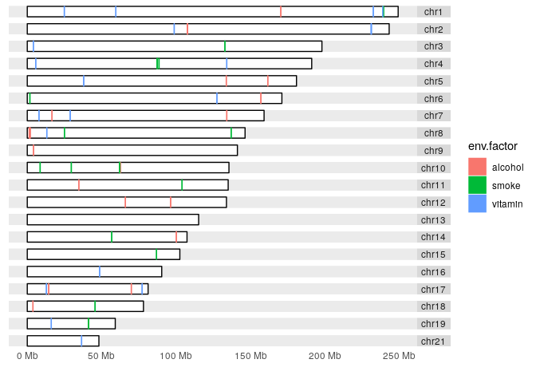

Overview of SNPs location, EU population.

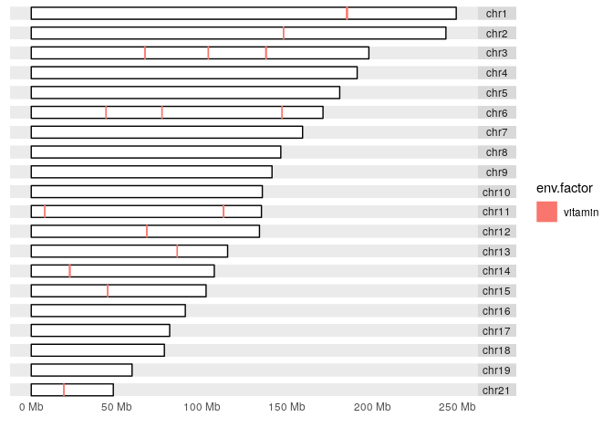

Overview of SNPs location, Asia population.

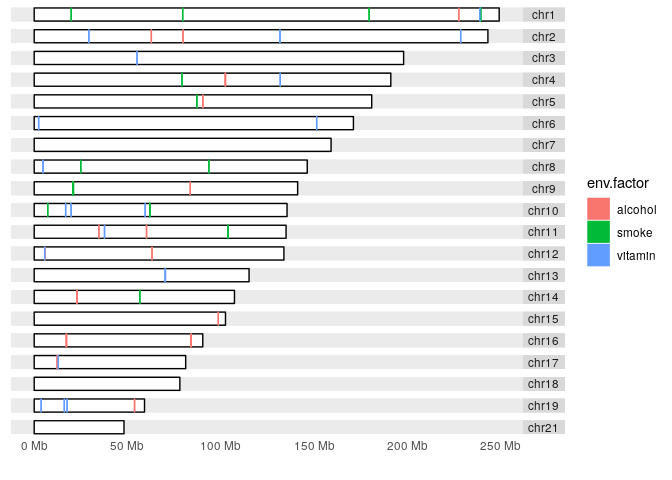

Overview of SNPs location, pooled.

It doesn’t seem like the SNPs cluster.

# Features by genomic region

## Combining information about regulatory features and genes

How many SNPs are in a gene or a regulatory region?

```
## # A tibble: 63 x 3
## # Groups:   chr_name [20]
##    chr_name feature_type             count
##       <int> <chr>                    <int>
##  1        1 <NA>                         7
##  2        1 enhancer                     1
##  3        1 gene                         4
##  4        1 open_chromatin_region        1
##  5        1 promoter_flanking_region     2
##  6        2 <NA>                         2
##  7        2 enhancer                     1
##  8        2 gene                         6
##  9        2 promoter_flanking_region     1
## 10        2 TF_binding_site              1
## 11        3 <NA>                         3
```

[output cut: 52 more lines]

## Plotting

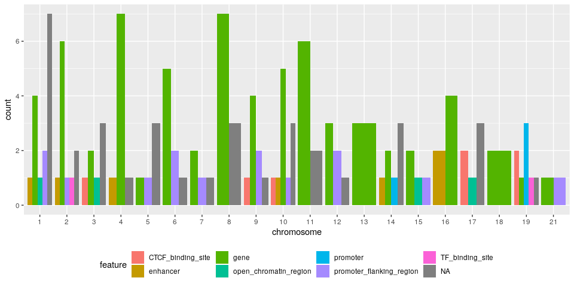

# Hetionet querying

## Trying with the most significant result from the manuscript:

```
MATCH path = allShortestPaths((node1:Gene {name: 'ARHGEF10'})-[*..3]-(node2:Disease {identifier: "DOID:0050741"}))
WITH relationships(path) AS rels
UNWIND rels AS rel
RETURN
DISTINCT startNode(rel) AS source, endNode(rel) AS target, rel AS relationship
UNION
MATCH path = allShortestPaths((node1:Gene {name: 'ARHGEF10'})-[*..2]-(node2:Disease {name: 'cleft lip'}))
WITH relationships(path) AS rels UNWIND rels AS rel
RETURN
DISTINCT startNode(rel) AS source, endNode(rel) AS target, rel AS relationship
```

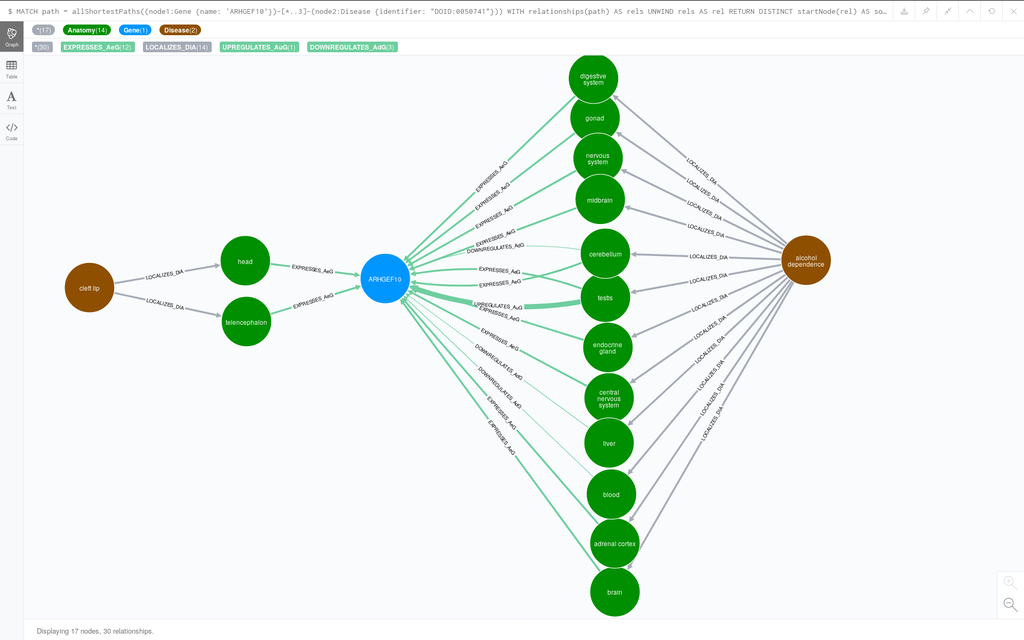

Hetionet result for the query above.

## Getting all the genes associated with ‘alcohol dependence’

Data from OpenTargets: https://www.targetvalidation.org/disease/EFO_0003829/associations?fcts=datatype:genetic_association (alcohol dependence defined as EFO_0003829 or DOID:0050741)

```
##    target.gene_info.symbol       target.id association_score.overall
## 1                    ALDH2 ENSG00000111275                 1.0000000
## 2                    ADH1B ENSG00000196616                 1.0000000
## 3                   GABRG1 ENSG00000163285                 1.0000000
## 4                     OXTR ENSG00000180914                 1.0000000
## 5                   SCN10A ENSG00000185313                 1.0000000
## 6                    ADH1C ENSG00000248144                 0.7292360
## 7                   SEMA3A ENSG00000075213                 0.4636220
## 8                    MTIF2 ENSG00000085760                 0.4001649
## 9                  SERINC2 ENSG00000168528                 0.3412053
## 10                   FSTL5 ENSG00000168843                 0.3338266
##    association_score.datatypes.genetic_association
## 1                                     0.4953492213
## 2                                     1.0000000000
## 3                                     0.1493040668
```

[output cut: 84 more lines]

I will take the first 6, since the score is higher than 0.5 for those.

```
## [1] ALDH2  ADH1B  GABRG1 OXTR   SCN10A ADH1C
## 325 Levels: ABCA1 ABI3BP ACBD4 ACKR1 ACKR3 ADAM17 ADAM19 ... ZNF827
```

Thus, the query will be:

```
MATCH path = allShortestPaths((node1:Gene {name: 'ARHGEF10'})-[*..2]-(node2:Gene))
WHERE node2.name IN ["ALDH2","ADH1B","GABRG1","OXTR","SCN10A","ADH1C"]
WITH relationships(path) AS rels
UNWIND rels AS rel
RETURN
DISTINCT startNode(rel) AS source, endNode(rel) AS target, rel AS relationship
UNION
MATCH path = allShortestPaths((node1:Gene {name: 'ARHGEF10'})-[*..2]-(node2:Disease {name: 'cleft lip'}))
WITH relationships(path) AS rels UNWIND rels AS rel
RETURN
DISTINCT startNode(rel) AS source, endNode(rel) AS target, rel AS relationship
```

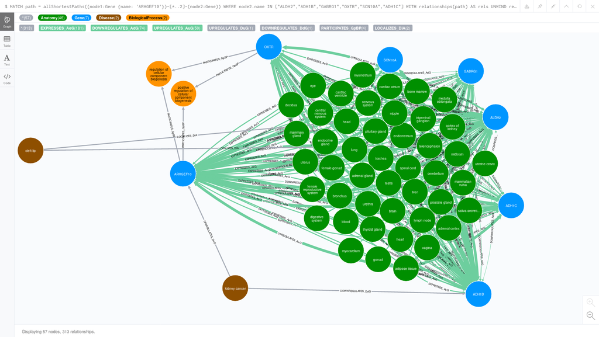

Hetionet result for the query above.

## Taking all the genes in PoOxAlcohol, EU

```
##    refsnp_id regulatory_stable_id feature_type chr_name chrom_start
## 1  rs7945550                 <NA>         gene       11    34656664
## 2  rs2294035                 <NA>         gene        8     1857293
## 3  rs4876274                 <NA>         gene        8     1857701
## 4   rs927318                 <NA>         gene        9     4172815
## 5 rs10735337                 <NA>         gene       12    96329934
## 6 rs12669493                 <NA>         gene        7    16601849
## 7   rs943881                 <NA>         gene       14   100166300
## 8  rs7232492                 <NA>         gene       18     3830245
## 9 rs11242213                 <NA>         gene        5   133720011
##   ensembl_gene_stable_id external_gene_name
## 1        ENSG00000135373                EHF
## 2        ENSG00000104728           ARHGEF10
## 3        ENSG00000104728           ARHGEF10
## 4        ENSG00000107249              GLIS3
## 5        ENSG00000165972             CCDC38
## 6        ENSG00000205858             LRRC72
## 7        ENSG00000036530            CYP46A1
## 8        ENSG00000170579             DLGAP1
## 9        ENSG00000119048              UBE2B
```

Query:

```
MATCH path = allShortestPaths((node1:Gene)-[*..2]-(node2:Disease {identifier: "DOID:0050741"}))
WHERE node1.name IN ["ARHGEF10","GLIS3","CCDC38","LRRC72","DLGAP2","CYP46A1","EHF","DLGAP1","UBE2B"]
WITH relationships(path) AS rels
UNWIND rels AS rel
RETURN DISTINCT startNode(rel) AS source, endNode(rel) AS target, rel AS relationship
UNION
MATCH path = allShortestPaths((node1:Gene)-[*..2]-(node2:Disease {name: 'cleft lip'}))
WHERE node1.name IN ["ARHGEF10","GLIS3","CCDC38","LRRC72","DLGAP2","CYP46A1","EHF","DLGAP1","UBE2B"]
WITH relationships(path) AS rels
UNWIND rels AS rel
RETURN DISTINCT startNode(rel) AS source, endNode(rel) AS target, rel AS relationship
```

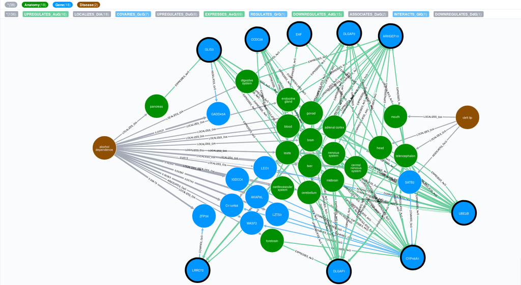

Hetionet result for the query above.

### Network analysis

Altogether, there were 136 relationships and 38 nodes.

1. Are there nodes common for all three parts (i.e., one of the genes in the gene list, “cleft lip”, and “alcohol dependence”)?

There are 0 nodes common to all three parts.

2. This is the shortest path from “cleft lip” to “alcohol dependence”:

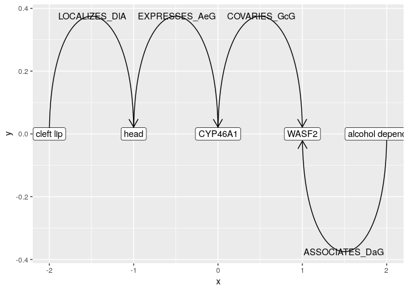

There are many other shortest paths… Let’s re-draw using weights for edges:

- “UPREGULATES_AuG”, “DOWNREGULATES_AdG”, “UPREGULATES_DuG”, “DOWNREGULATES_DdG” get the heighest weight,
- “REGULATES_GrG”, “EXPRESSES_AeG” get the middle weight, and
- “COVARIES_GcG” get the lowest weight (this edge basically means that the two genes have similar evolutionary histories, which is a proxy for being co-dependent, but still it’s just a proxy)

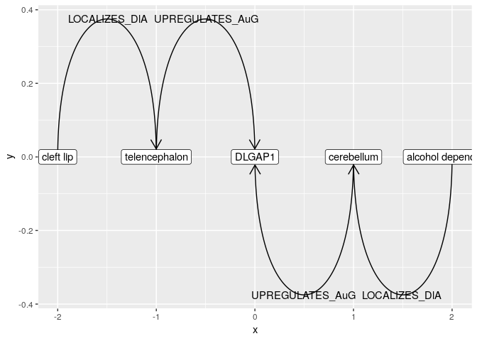

3. How many of the genes share their neighbourhood nodes?

Here are the neighboring nodes to the genes, along with the number of genes that point to those:

```
##    sum              node.name
## 1    7                  brain
## 2    7                  ZFP36
## 3    6                 testis
## 4    6                  gonad
## 5    5       digestive system
## 6    5                GADD45A
## 7    5                  liver
## 8    5         adrenal cortex
## 9    5                  LZTS3
## 10   4               pancreas
## 11   4                  blood
## 12   4               midbrain
## 13   4                 AKAP8L
## 14   2        endocrine gland
## 15   2             cerebellum
## 16   1              forebrain
## 17   1 central nervous system
## 18   1                  WASF2
## 19   1                 IGDCC4
## 20   1               C11orf68
## 21   1         nervous system
## 22   1                   LEO1
## 23   1  cardiovascular system
## 24   1                   head
## 25   1                  mouth
## 26   1          telencephalon
## 27   1                  SATB2
```

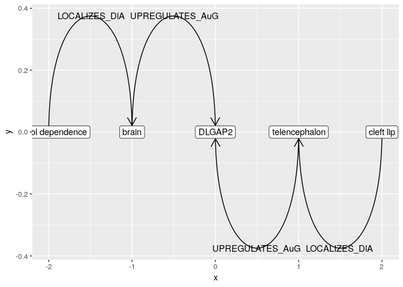

## Taking all the genes in PoOxSmoke, EU

```
##     refsnp_id regulatory_stable_id feature_type chr_name chrom_start
## 1   rs8181543                 <NA>         gene       11   104017037
## 2   rs3793861                 <NA>         gene       10    61945013
## 3  rs10763707                 <NA>         gene       10    29594791
## 4   rs2904096                 <NA>         gene        4    87304127
## 5   rs6532013                 <NA>         gene        4    88553414
## 6   rs6807522                 <NA>         gene        3   132815704
## 7  rs17604550                 <NA>         gene       15    86854757
## 8  rs17604550                 <NA>         gene       15    86854757
## 9   rs7234787                 <NA>         gene       18    45561707
## 10  rs4310561                 <NA>         gene       10    61954476
## 11  rs3800036                 <NA>         gene        6     1760556
##    ensembl_gene_stable_id external_gene_name
## 1         ENSG00000170962              PDGFD
## 2         ENSG00000151150               ANK3
## 3         ENSG00000120563              LYZL1
## 4         ENSG00000109339             MAPK10
## 5         ENSG00000249001      RP11-742B18.1
## 6         ENSG00000144868            TMEM108
## 7         ENSG00000260125          AGBL1-AS1
## 8         ENSG00000166748              AGBL1
## 9         ENSG00000184828             ZBTB7C
## 10        ENSG00000151150               ANK3
## 11        ENSG00000112699               GMDS
```

Query:

```
MATCH path = allShortestPaths((node1:Gene)-[*..2]-(node2:Disease))
WHERE node1.name IN ["LYZL1","ANK3","SHKBP1","MAPK10","TMEM108","AGBL1","PELI2","ZBTB7C","PDGFD","GMDS"]
and node2.name STARTS WITH "nicotine"
WITH relationships(path) AS rels
UNWIND rels AS rel
RETURN DISTINCT startNode(rel) AS source, endNode(rel) AS target, rel AS relationship
UNION
MATCH path = allShortestPaths((node1:Gene)-[*..2]-(node2:Disease {name: 'cleft lip'}))
WHERE node1.name IN ["LYZL1","ANK3","SHKBP1","MAPK10","TMEM108","AGBL1","PELI2","ZBTB7C","PDGFD","GMDS"]
WITH relationships(path) AS rels
UNWIND rels AS rel
RETURN DISTINCT startNode(rel) AS source, endNode(rel) AS target, rel AS relationship
```

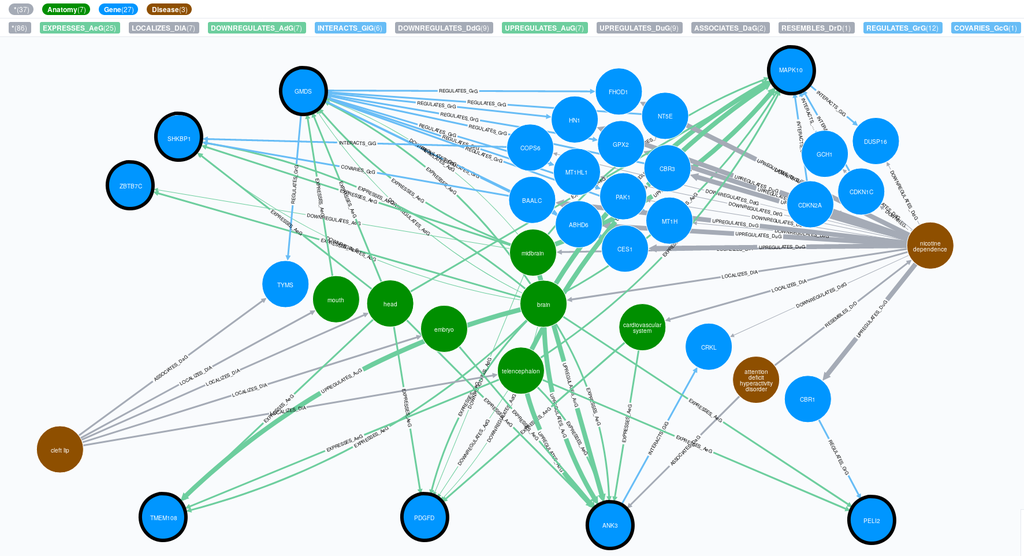

Hetionet result for the query above.

### Network analysis

Altogether, there were 86 relationships and 37 nodes.

There are 0 nodes common to all three parts.

6. This is the shortest path from “cleft lip” to “nicotine dependence”:

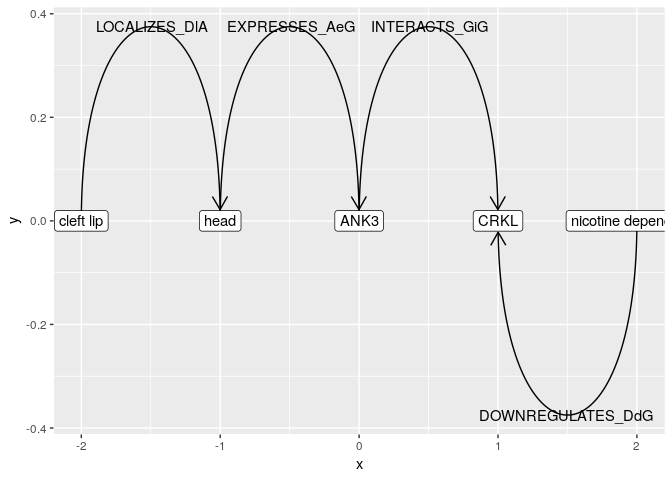

There are many other shortest paths… Let’s re-draw using weights for edges:

- “ASSOCIATES_DaG” (this means that there is a GWAS association) and “INTERACTS_GiG” (interaction based on the literature evidence) get the highest weight,
- “UPREGULATES_AuG”, “DOWNREGULATES_AdG”, “UPREGULATES_DuG”, “DOWNREGULATES_DdG” get the second heighest weight,
- “REGULATES_GrG”, “EXPRESSES_AeG” get the middle weight, and
- “COVARIES_GcG” get the lowest weight (this edge basically means that the two genes have similar evolutionary histories, which is a proxy for being co-dependent, but still it’s just a proxy)

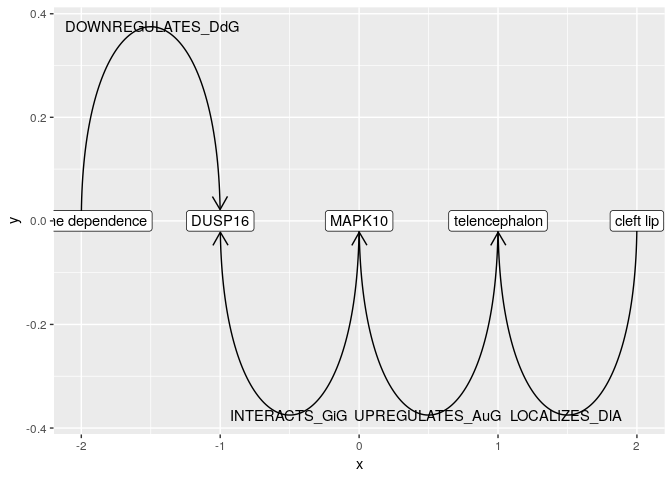

7. How many of the genes share their neighbourhood nodes?

Here are the neighboring nodes to the genes, along with the number of genes that point to those:

```
##    sum                                node.name
## 1    6                                    brain
## 2    5                                 midbrain
## 3    5                    cardiovascular system
## 4    4                                     CBR3
## 5    2                                   CDKN2A
## 6    1                                   DUSP16
## 7    1                                   CDKN1C
## 8    1                                     GCH1
## 9    1 attention deficit hyperactivity disorder
## 10   1                                     CRKL
## 11   1                                     CES1
## 12   1                                     NT5E
## 13   1                                    ABHD6
## 14   1                                     MT1H
## 15   1                                     PAK1
## 16   1                                   MT1HL1
## 17   1                                     GPX2
## 18   1                                      HN1
## 19   1                                    FHOD1
## 20   1                                     head
## 21   1                            telencephalon
## 22   1                                   embryo
## 23   1                                    mouth
## 24   1                                     TYMS
```

8. What is the shortest path going from “cleft lip” to “nicotine dependence” through one of those most shared nodes? (using the weighted edges, as above)

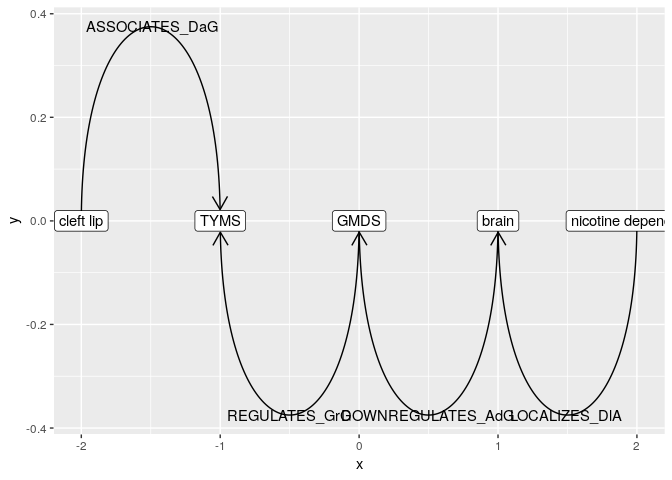

# Protein-protein interaction network

## Genes from PoOxAlcohol, EU

Querying STRING.db with the genes ARHGEF10, GLIS3, CCDC38, LRRC72, DLGAP2, CYP46A1, EHF, DLGAP1, UBE2B, gave the following output:

[figure not shown]

STRING PPI

[Here is the network](https://version-11-0.string-db.org/cgi/network.pl?networkId=QHo4OmUrJdbe)

## Genes from PoOxSmoke, EU

[figure not shown]

STRING PPI

[Here is the network](https://version-11-0.string-db.org/cgi/network.pl?networkId=s5g9jPvu1Xtz)

# Gene set enrichment

Querying ExpressionAtlas for enrichment didn’t return any results.

```
ENSG00000111275,ENSG00000196616,ENSG00000163285,ENSG00000180914,
ENSG00000185313,ENSG00000248144,ENSG00000104728
```

Querying Bgee (https://bgee.org/)

1. First, checking the genes found for PoOxAlcohol, pooled results, with all embryonic-stage genes as the background:

[output not shown]

[output not shown]

[output cut: 45 more lines]

[output not shown]

[output not shown]

[output not shown]

[output cut: 170 more lines]

[output not shown]

```
##     0     1
## 41145     9
```

```
##  [1] "ENSG00000047617" "ENSG00000140943" "ENSG00000135373"
##  [4] "ENSG00000066032" "ENSG00000140943" "ENSG00000166930"
##  [7] "ENSG00000111110" "ENSG00000153064" "ENSG00000153064"
## [10] "ENSG00000103489" "ENSG00000103489" "ENSG00000164199"
```

```
##  [1] "ANO2"   "MBTPS1" "EHF"    "CTNNA2" "MBTPS1" "MS4A5"  "PPM1H"
##  [8] "BANK1"  "BANK1"  "XYLT1"  "XYLT1"  "GPR98"
```

```
##
## Checking topAnatData object.............
##
## Checking gene list......................
##
## Building most specific Ontology terms...  (  6  Ontology terms found. )
##
## Building DAG topology...................  (  65  Ontology terms and  95  relations. )
##
## Annotating nodes (Can be long)..........  (  41154  genes annotated to the Ontology terms. )
```

```
##
## WARNING: there was no significant term at FDR threshold of 0.01
```

2. checking the genes found for PoOxSmoke, pooled results:

```
##     0     1
## 41147     7
```

```
##  [1] "ENSG00000188352" "ENSG00000188352" "ENSG00000188352"
##  [4] "ENSG00000188352" "ENSG00000188352" "ENSG00000198879"
##  [7] "ENSG00000116218" "ENSG00000188352" "ENSG00000170962"
## [10] "ENSG00000138759" "ENSG00000139946" "ENSG00000170962"
## [13] "ENSG00000151150" "ENSG00000151150"
```

```
##  [1] "FOCAD"  "FOCAD"  "FOCAD"  "FOCAD"  "FOCAD"  "SFMBT2" "NPHS2"
##  [8] "FOCAD"  "PDGFD"  "FRAS1"  "PELI2"  "PDGFD"  "ANK3"   "ANK3"
```

```
##
## Checking topAnatData object.............
##
## Checking gene list......................
##
## Building most specific Ontology terms...  (  6  Ontology terms found. )
##
## Building DAG topology...................  (  65  Ontology terms and  95  relations. )
##
## Annotating nodes (Can be long)..........  (  41154  genes annotated to the Ontology terms. )
```

```
##
## WARNING: there was no significant term at FDR threshold of 0.01
```